# Hierarchical model

Rabeez Riaz

3/9/2022

## Motivation

To model discrete heterogeneity we can use hierarchical (multi-level) models to effectively incorporate information from multiple groups. We will use a Bayesian hierarchical model. This approach has 3 main advantages: 1. The Bayesian modelling approach allows for setting of priors which can incorporate domain knowledge 2. Due to the ‘pooling’ effect the estimated parameters are more stable 3. If a certain group has a small sample size, we can still estimate parameters for it reasonably well assuming the priors are not completely horrible because we can incorporate information from the other groups with larger samples

https://www.youtube.com/watch?v=dNZQrcAjgXQ

## Dataset

```r
df <- read_csv(
  "https://raw.githubusercontent.com/MaggieLieu/STAN_tutorials/master/Hierarchical/premiereleague.csv",
  col_names = c("home_team", "home_score", "away_score", "away_team")
)
all_teams <- sort(unique(c(df$home_team, df$away_team))) %>%
  setNames(as.list(seq(1, length(.))), .) %>%
  as_tibble() %>%
  gather()

df <- df %>%
  left_join(all_teams %>% rename(home_team_idx = value), by = c("home_team" = "key")) %>%
  left_join(all_teams %>% rename(away_team_idx = value), by = c("away_team" = "key"))


data <- list(
  num_teams = nrow(all_teams),
  num_games = nrow(df),
  home_team_idx = df$home_team_idx,
  away_team_idx = df$away_team_idx,
  home_team_score = df$home_score,
  away_team_score = df$away_score
)
```

## Model definition

number of goals ~ poisson (count) where rate parameter of poisson (theta) is the expected score

for a match between TEAM1 (home) and TEAM2 (away) the expected scores are: theta_TEAM1 = exp(home_advantage_factor + attack_ability_TEAM1 - defense_ability_TEAM2) theta_TEAM2 = exp(attack_ability_TEAM2 - defense_ability_TEAM1) ^ take exp to make positive

```stan
// This stan chunk results in a CmdStanModel object called "model"
data {
  int<lower=0> num_teams;
  int<lower=0> num_games;
  int<lower=0> home_team_idx[num_games];
  int<lower=0> away_team_idx[num_games];
  int<lower=0> home_team_score[num_games];
  int<lower=0> away_team_score[num_games];
}

parameters {
  real home_adv;
  vector[num_teams] attack_ability;
  vector[num_teams] defense_ability;

  // hyper parameters
  real mu_attack;
  real<lower=0> tau_attack;
  real mu_defense;
  real<lower=0> tau_defense;
}

transformed parameters {
  vector[num_games] theta1;
  vector[num_games] theta2;

  theta1 = exp(home_adv + attack_ability[home_team_idx] - defense_ability[away_team_idx]);
  theta2 = exp(attack_ability[away_team_idx] - defense_ability[home_team_idx]);
}

model {
  // hyper priors
  mu_attack ~ normal(0, 0.1);
  tau_attack ~ normal(0, 1);
  mu_defense ~ normal(0, 0.1);
  tau_defense ~ normal(0, 1);

  // priors
  attack_ability ~ normal(mu_attack, tau_attack);
  defense_ability ~ normal(mu_defense, tau_defense);
  home_adv ~ normal(0, 0.001);

  // likelihood
  home_team_score ~ poisson(theta1);
  away_team_score ~ poisson(theta2);
}
```

## Model fitting

```r
# model$print()

fit <- model$sample(
  data = data,
  chains = 4,
  parallel_chains = 4,
  seed = 42L
)
```

```
## Running MCMC with 4 parallel chains...
##
## Chain 1 Iteration:    1 / 2000 [  0%]  (Warmup)
```

```
## Chain 1 Informational Message: The current Metropolis proposal is about to be rejected because of the following issue:
```

[output not shown]

```
## Chain 1 If this warning occurs sporadically, such as for highly constrained variable types like covariance matrices, then the sampler is fine,
```

```
## Chain 1 but if this warning occurs often then your model may be either severely ill-conditioned or misspecified.
```

```
## Chain 1
```

```
## Chain 2 Iteration:    1 / 2000 [  0%]  (Warmup)
```

```
## Chain 2 Informational Message: The current Metropolis proposal is about to be rejected because of the following issue:
```

[output not shown]

```
## Chain 2 If this warning occurs sporadically, such as for highly constrained variable types like covariance matrices, then the sampler is fine,
```

```
## Chain 2 but if this warning occurs often then your model may be either severely ill-conditioned or misspecified.
```

```
## Chain 2
```

```
## Chain 3 Iteration:    1 / 2000 [  0%]  (Warmup)
```

```
## Chain 3 Informational Message: The current Metropolis proposal is about to be rejected because of the following issue:
```

[output not shown]

```
## Chain 3 If this warning occurs sporadically, such as for highly constrained variable types like covariance matrices, then the sampler is fine,
```

```
## Chain 3 but if this warning occurs often then your model may be either severely ill-conditioned or misspecified.
```

```
## Chain 3
```

[output not shown]

[output cut: 38 more lines]

[output not shown]

```
##
## Warning: 1 of 4000 (0.0%) transitions ended with a divergence.
## This may indicate insufficient exploration of the posterior distribution.
## Possible remedies include:
##   * Increasing adapt_delta closer to 1 (default is 0.8)
##   * Reparameterizing the model (e.g. using a non-centered parameterization)
##   * Using informative or weakly informative prior distributions
```

## Findings

```r
model_summary <- fit$summary()
model_summary
```

```
## # A tibble: 704 x 10
##    variable       mean   median      sd     mad       q5      q95  rhat ess_bulk
##    <chr>         <dbl>    <dbl>   <dbl>   <dbl>    <dbl>    <dbl> <dbl>    <dbl>
##  1 lp__       -5.38e+2 -5.38e+2 5.36    5.14    -5.47e+2 -5.30e+2  1.00    1144.
##  2 home_adv    3.81e-5  3.46e-5 0.00101 0.00105 -1.62e-3  1.65e-3  1.00    4124.
##  3 attack_a~  -9.14e-2 -8.95e-2 0.167   0.169   -3.73e-1  1.79e-1  1.00    2068.
##  4 attack_a~   2.33e-1  2.34e-1 0.150   0.152   -1.56e-2  4.72e-1  1.00    1507.
##  5 attack_a~  -2.41e-3 -4.36e-4 0.162   0.162   -2.72e-1  2.64e-1  1.00    1918.
##  6 attack_a~  -3.79e-2 -3.45e-2 0.159   0.157   -3.07e-1  2.22e-1  1.00    2105.
##  7 attack_a~   9.95e-3  1.13e-2 0.163   0.164   -2.59e-1  2.76e-1  1.00    1935.
##  8 attack_a~   3.97e-1  3.99e-1 0.148   0.148    1.45e-1  6.40e-1  1.00    1444.
##  9 attack_a~  -1.94e-1 -1.90e-1 0.173   0.172   -4.85e-1  9.04e-2  1.00    2153.
## 10 attack_a~   9.94e-2  9.97e-2 0.159   0.154   -1.70e-1  3.58e-1  1.00    1787.
## # ... with 694 more rows, and 1 more variable: ess_tail <dbl>
```

```r
model_summary_ <- model_summary %>%
  filter(str_detect(variable, "_ability")) %>%
  mutate(
    team_idx = as.integer(str_extract(variable, "\\d+")),
    type = str_match(variable, "(.*)_ability.*")[,2]
  ) %>%
  left_join(all_teams %>% rename(team_name = key), by = c("team_idx" = "value")) %>%
  select(team_name, type, mean, median, sd, q5, q95)
model_summary_
```

```
## # A tibble: 40 x 7
##    team_name              type       mean    median    sd      q5    q95
##    <chr>                  <chr>     <dbl>     <dbl> <dbl>   <dbl>  <dbl>
##  1 AFC Bournemouth        attack -0.0914  -0.0895   0.167 -0.373  0.179
##  2 Arsenal                attack  0.233    0.234    0.150 -0.0156 0.472
##  3 Aston Villa            attack -0.00241 -0.000436 0.162 -0.272  0.264
##  4 Brighton & Hove Albion attack -0.0379  -0.0345   0.159 -0.307  0.222
##  5 Burnley                attack  0.00995  0.0113   0.163 -0.259  0.276
##  6 Chelsea                attack  0.397    0.399    0.148  0.145  0.640
##  7 Crystal Palace         attack -0.194   -0.190    0.173 -0.485  0.0904
##  8 Everton                attack  0.0994   0.0997   0.159 -0.170  0.358
##  9 Leicester City         attack  0.441    0.442    0.141  0.200  0.669
## 10 Liverpool              attack  0.560    0.563    0.140  0.325  0.790
## # ... with 30 more rows
```

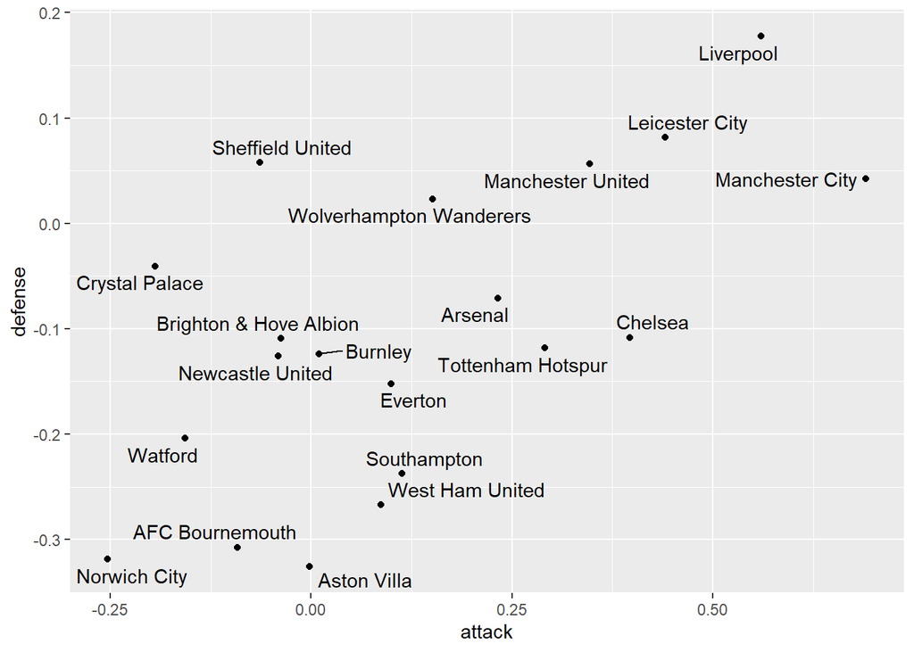

```r
model_summary_ %>%
  pivot_wider(id_cols = team_name, names_from = type, values_from = mean) %>%
  ggplot(aes(
    x = attack,
    y = defense,
    label = team_name
  )) +
  geom_point() +
  ggrepel::geom_text_repel()
```

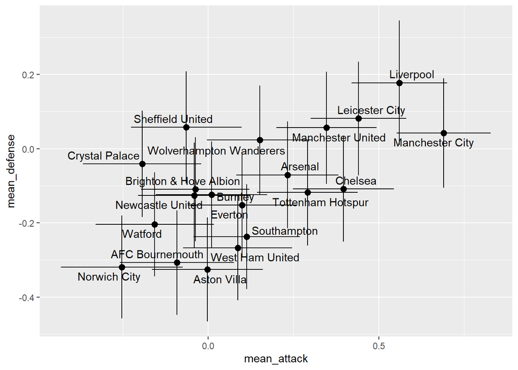

```r
model_summary_ %>%
  pivot_wider(id_cols = team_name, names_from = type, values_from = c(mean, sd, q5, q95)) %>%
  ggplot(aes(
    x = mean_attack,
    y = mean_defense,
    label = team_name
  )) +
  geom_point() +
  geom_pointrange(aes(
    xmin = mean_attack - sd_attack,
    xmax = mean_attack + sd_attack
  )) +
  geom_pointrange(aes(
    ymin = mean_defense - sd_defense,
    ymax = mean_defense + sd_defense
  )) +
  # geom_pointrange(aes(
  #   xmin = q5_attack,
  #   xmax = q95_attack
  # )) +
  # geom_pointrange(aes(
  #   ymin = q5_defense,
  #   ymax = q95_defense
  # )) +
  ggrepel::geom_text_repel()
```